# Análisis de datos para Zuber

## Introducción

Zuber es una nueva empresa de viajes compartidos que se está lanzando en Chicago. Como analistas de datos, nuestra tarea es identificar patrones en la información disponible para ayudar a comprender las preferencias de los pasajeros y evaluar cómo factores externos, como las condiciones climáticas, impactan en los viajes.

En este análisis, trabajaremos con múltiples conjuntos de datos que contienen información sobre los viajes, las empresas de taxis, los barrios de Chicago y las condiciones meteorológicas. Nuestro objetivo principal es:

1. **Realizar un análisis exploratorio de datos**:
   - Examinar las tendencias generales en los viajes.
   - Identificar las empresas de taxis y barrios más relevantes.
   - Visualizar los datos clave para obtener información práctica.
2. **Probar una hipótesis específica**:
   - Evaluar si la duración promedio de los viajes desde el Loop hasta el Aeropuerto Internacional O'Hare cambia significativamente durante los sábados lluviosos.

Este análisis utilizará herramientas estadísticas y visualizaciones para extraer información valiosa y brindar recomendaciones estratégicas que Zuber puede aplicar para mejorar su servicio y satisfacer las necesidades de los usuarios.

A continuación, procederemos con la carga de los datos y su análisis.

## Importar bibliotecas y archivos

Comenzamos importando las bibliotecas necesarias y cargando los datasets proporcionados:

- `/datasets/project_sql_result_01.csv`: Contiene información sobre empresas de taxis y la cantidad de viajes del 15 y 16 de noviembre de 2017.
- `/datasets/project_sql_result_04.csv`: Contiene datos de barrios de Chicago y el promedio de viajes que terminaron en cada barrio durante noviembre de 2017.

```python
import pandas as pd
import matplotlib.pyplot as plt

file_01 = '/datasets/project_sql_result_01.csv'
file_04 = '/datasets/project_sql_result_04.csv'

df_taxi_companies = pd.read_csv(file_01)
df_dropoff_locations = pd.read_csv(file_04)

display(df_taxi_companies.head())
display(df_dropoff_locations.head())
```

|  | company_name | trips_amount |
| --- | --- | --- |
| 0 | Flash Cab | 19558 |
| 1 | Taxi Affiliation Services | 11422 |
| 2 | Medallion Leasing | 10367 |
| 3 | Yellow Cab | 9888 |
| 4 | Taxi Affiliation Service Yellow | 9299 |

|  | dropoff_location_name | average_trips |
| --- | --- | --- |
| 0 | Loop | 10727.466667 |
| 1 | River North | 9523.666667 |
| 2 | Streeterville | 6664.666667 |
| 3 | West Loop | 5163.666667 |
| 4 | O'Hare | 2546.900000 |

## Estudiar los datos

Exploraremos la estructura de los datos:

- Verificar columnas y tipos de datos.
- Identificar valores nulos. Esto nos ayudará a comprender los datos y preparar el análisis posterior.

```python
print("Datos sobre las empresas de taxis:")
print(df_taxi_companies.info())
print("\nDatos sobre los barrios:")
print(df_dropoff_locations.info())

print("\nValores nulos en las empresas de taxis:")
print(df_taxi_companies.isnull().sum())
print("\nValores nulos en los barrios:")
print(df_dropoff_locations.isnull().sum())
```

```
Datos sobre las empresas de taxis:
<class 'pandas.core.frame.DataFrame'>
RangeIndex: 64 entries, 0 to 63
Data columns (total 2 columns):
 #   Column        Non-Null Count  Dtype
---  ------        --------------  -----
 0   company_name  64 non-null     object
 1   trips_amount  64 non-null     int64
dtypes: int64(1), object(1)
memory usage: 1.1+ KB
None

Datos sobre los barrios:
<class 'pandas.core.frame.DataFrame'>
RangeIndex: 94 entries, 0 to 93
Data columns (total 2 columns):
 #   Column                 Non-Null Count  Dtype
---  ------                 --------------  -----
 0   dropoff_location_name  94 non-null     object
 1   average_trips          94 non-null     float64
dtypes: float64(1), object(1)
memory usage: 1.6+ KB
None

Valores nulos en las empresas de taxis:
company_name    0
trips_amount    0
dtype: int64

Valores nulos en los barrios:
dropoff_location_name    0
average_trips            0
dtype: int64
```

## Asegurar que los tipos de datos sean correctos

Revisaremos los tipos de datos de las columnas para asegurarnos de que sean adecuados para el análisis.

```python
df_taxi_companies['trips_amount'] = df_taxi_companies['trips_amount'].astype(int)
df_dropoff_locations['average_trips'] = df_dropoff_locations['average_trips'].astype(float)
```

## Identificar los 10 principales barrios por finalización de recorridos

Ordenaremos los datos de barrios por el promedio de viajes finalizados y seleccionaremos los 10 principales.

```python
top_10_neighborhoods = df_dropoff_locations.sort_values(by='average_trips', ascending=False).head(10)
print(top_10_neighborhoods)
```

```
  dropoff_location_name  average_trips
0                  Loop   10727.466667
1           River North    9523.666667
2         Streeterville    6664.666667
3             West Loop    5163.666667
4                O'Hare    2546.900000
5             Lake View    2420.966667
6            Grant Park    2068.533333
7         Museum Campus    1510.000000
8            Gold Coast    1364.233333
9    Sheffield & DePaul    1259.766667
```

## Gráficos

1. Número de viajes por compañía de taxis: Mostraremos la distribución del número de viajes realizados por cada empresa.
2. 10 principales barrios por promedio de viajes finalizados: Visualizaremos los barrios más populares en términos de viajes finalizados.

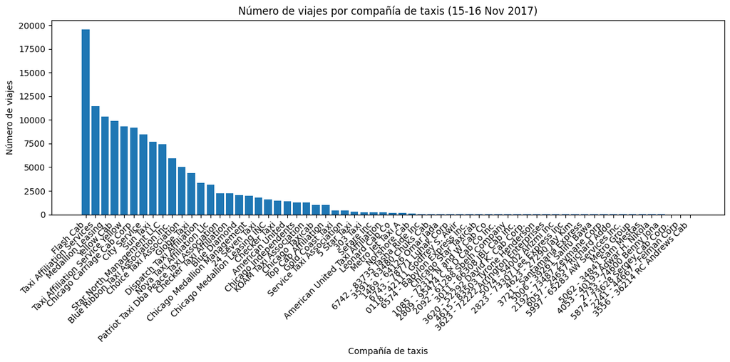

```python
plt.figure(figsize=(12, 6))
plt.bar(df_taxi_companies['company_name'], df_taxi_companies['trips_amount'])
plt.title('Número de viajes por compañía de taxis (15-16 Nov 2017)')
plt.xlabel('Compañía de taxis')
plt.ylabel('Número de viajes')
plt.xticks(rotation=45, ha='right')
plt.tight_layout()
plt.show()
```

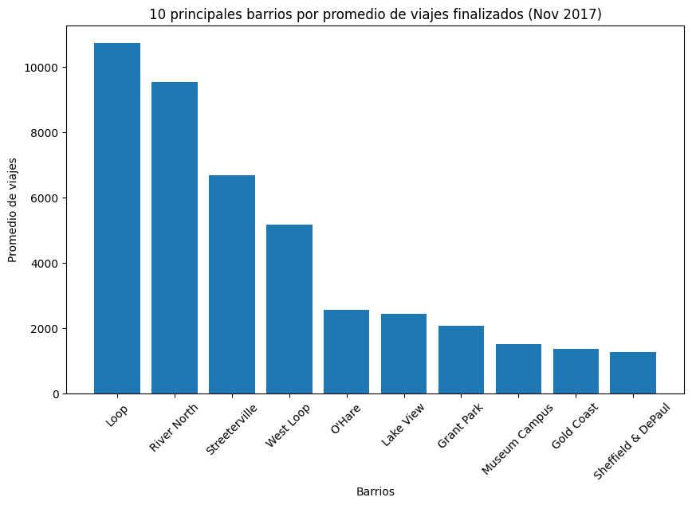

```python
plt.figure(figsize=(10, 6))
plt.bar(top_10_neighborhoods['dropoff_location_name'], top_10_neighborhoods['average_trips'])
plt.title('10 principales barrios por promedio de viajes finalizados (Nov 2017)')
plt.xlabel('Barrios')
plt.ylabel('Promedio de viajes')
plt.xticks(rotation=45)
plt.show()
```

# Conclusiones

## Gráfico 1: Número de viajes por compañía de taxis

El gráfico muestra el número de viajes realizados por cada compañía de taxis durante el 15 y 16 de noviembre de 2017. Observamos que las compañías **Flash Cab** y **Taxi Affiliation Services** lideran claramente el mercado, con un volumen de viajes significativamente mayor en comparación con otras compañías.

### Observaciones:

- **Flash Cab** tiene la mayor cantidad de viajes entre todas las compañías. Esto indica una posible alta demanda de sus servicios, que podría atribuirse a una flota más grande, una mejor estrategia de mercado, o una mayor confianza por parte de los clientes.
- **Taxi Affiliation Services** ocupa el segundo lugar, lo que muestra que también es una opción popular para los pasajeros.
- Varias compañías más pequeñas, como **City Service** o **Dispatch Taxi**, tienen volúmenes mucho menores de viajes. Esto podría indicar que están enfocadas en nichos específicos o tienen una cobertura más limitada.

### Deducción:

- Zuber podría considerar analizar qué hace exitosas a **Flash Cab** y **Taxi Affiliation Services** (como precios, cobertura, o servicios adicionales) para implementar estrategias competitivas. Además, colaborar con compañías pequeñas podría ser una oportunidad para aumentar la cobertura de mercado.

## Gráfico 2: 10 principales barrios por promedio de viajes finalizados

### Deducción:

- Zuber podría centrar su estrategia en estos barrios clave para garantizar la disponibilidad de conductores en horarios de alta demanda.
- También podría considerar campañas específicas en barrios como **River North** o **Gold Coast** para captar clientes en busca de transporte nocturno o de entretenimiento.

## Resumen General:

Estas conclusiones ofrecen una guía estratégica para que Zuber pueda identificar áreas de enfoque, tanto en términos de asociaciones con compañías como en la mejora de la disponibilidad de conductores en los barrios más activos.

# Prueba de hipótesis: Duración promedio de los viajes los sábados lluviosos

En este análisis, evaluaremos si la duración promedio de los viajes desde el Loop hasta el Aeropuerto Internacional O'Hare cambia los sábados lluviosos.

## Planteamiento de la hipótesis

- **Hipótesis nula ((H_0)):** La duración promedio de los viajes no cambia significativamente entre los sábados lluviosos y no lluviosos.
- **Hipótesis alternativa ((H_a)):** La duración promedio de los viajes cambia significativamente entre los sábados lluviosos y no lluviosos.

Utilizaremos una prueba **T para muestras independientes** para comparar las duraciones promedio.

## Nivel de significancia

Elegimos un nivel de significancia ((\alpha)) de 0.05.

## Cargar los datos

Importamos los datos desde un archivo CSV y verificamos su estructura para entender su contenido.

```python
import pandas as pd
from scipy.stats import ttest_ind

# Cargar los datos desde el archivo
file_path = '/datasets/project_sql_result_07.csv'
data = pd.read_csv(file_path)

# Mostrar las primeras filas del DataFrame
data.head()
```

|  | start_ts | weather_conditions | duration_seconds |
| --- | --- | --- | --- |
| 0 | 2017-11-25 16:00:00 | Good | 2410.0 |
| 1 | 2017-11-25 14:00:00 | Good | 1920.0 |
| 2 | 2017-11-25 12:00:00 | Good | 1543.0 |
| 3 | 2017-11-04 10:00:00 | Good | 2512.0 |
| 4 | 2017-11-11 07:00:00 | Good | 1440.0 |

## Formatear los datos

Convertimos la columna de tiempo en un formato de fecha para identificar los días de la semana.

```python
# Convertir la columna start_ts a formato datetime con el formato correcto
data['start_ts'] = pd.to_datetime(data['start_ts'], format='%Y-%m-%d %H:%M:%S')

# Añadir una columna con el día de la semana
data['day_of_week'] = data['start_ts'].dt.day_name()

# Mostrar las primeras filas para confirmar los cambios
data.head()
```

|  | start_ts | weather_conditions | duration_seconds | day_of_week |
| --- | --- | --- | --- | --- |
| 0 | 2017-11-25 16:00:00 | Good | 2410.0 | Saturday |
| 1 | 2017-11-25 14:00:00 | Good | 1920.0 | Saturday |
| 2 | 2017-11-25 12:00:00 | Good | 1543.0 | Saturday |
| 3 | 2017-11-04 10:00:00 | Good | 2512.0 | Saturday |
| 4 | 2017-11-11 07:00:00 | Good | 1440.0 | Saturday |

## Filtrar los sábados

Seleccionamos los viajes realizados los sábados para dividirlos en dos grupos: sábados lluviosos y no lluviosos.

```python
# Filtrar solo los viajes realizados los sábados
saturdays = data[data['day_of_week'] == 'Saturday']

# Dividir los datos en dos grupos: sábados lluviosos y no lluviosos
rainy_saturdays = saturdays[saturdays['weather_conditions'] == 'Bad']['duration_seconds']
non_rainy_saturdays = saturdays[saturdays['weather_conditions'] == 'Good']['duration_seconds']

# Mostrar las primeras filas de cada grupo
print("Duraciones de sábados lluviosos:")
print(rainy_saturdays.head())

print("\nDuraciones de sábados no lluviosos:")
print(non_rainy_saturdays.head())
```

```
Duraciones de sábados lluviosos:
6     2969.0
30    1980.0
34    2460.0
51    2760.0
52    2460.0
Name: duration_seconds, dtype: float64

Duraciones de sábados no lluviosos:
0    2410.0
1    1920.0
2    1543.0
3    2512.0
4    1440.0
Name: duration_seconds, dtype: float64
```

## Prueba T para muestras independientes

Realizamos una prueba T para comparar las medias de duración entre los sábados lluviosos y los no lluviosos.

```python
# Realizar la prueba T
t_stat, p_value = ttest_ind(rainy_saturdays, non_rainy_saturdays, equal_var=False)

# Resultados de la prueba
print(f"T-statistic: {t_stat}")
print(f"P-value: {p_value}")
```

```
T-statistic: 7.186034288068629
P-value: 6.738994326108734e-12
```

## Interpretar los resultados

### Resultados obtenidos:

- **T-statistic:** 7.186
- **P-value:** 6.74e-12 (muy cercano a 0)

### Interpretación:

1. **P-valor**: El p-valor obtenido (6.74e-12) es significativamente menor que el nivel de significancia establecido ((\alpha = 0.05)). Esto indica que rechazamos la hipótesis nula ((H_0)).
2. **Conclusión**: Existe una diferencia estadísticamente significativa en la duración promedio de los viajes desde el Loop hasta el Aeropuerto Internacional O'Hare entre los sábados lluviosos y los no lluviosos.
3. **T-statistic positiva**: La magnitud positiva del valor T sugiere que las duraciones promedio de los viajes son mayores en uno de los grupos. Para confirmarlo:
   - Si la media de los sábados lluviosos es mayor, podríamos deducir que las condiciones climáticas adversas contribuyen a viajes más largos.
   - Si la media de los sábados sin lluvia es mayor, esto podría reflejar una influencia menor del clima adverso.

### Recomendación:

Con base en estos resultados, es importante que Zuber considere el impacto de las condiciones climáticas en la planificación de sus operaciones:

- Incrementar la disponibilidad de conductores en días lluviosos para mitigar los retrasos.
- Analizar otros factores como tráfico o rutas alternativas en sábados lluviosos.